# R Beginners Course 2026

Dr. Debasish Mukherjee, Dr. Ulrike Göbel, Dr. Ali Abdallah

Bioinformatics Core Facility CECAD

2026-05-11

**Session 2 :: Basic Concepts in R**

## Variables

- Variables are containers for storing data values.
- R does not have a command for declaring a variable
- A variable is created the moment you first assign a value to it.
- Assignment operator `<-` or `=` can be used for assigning a value

[figure not shown]

[figure not shown]

```r
# This is a comment

name <- "John"    # This is also a comment
age <- 40
name
```

```
[1] "John"
```

```r
name <- "Tom"
print (name)
```

```
[1] "Tom"
```

## Variable Names

Variable names may be short (like x and y) or descriptive (age, carname, total_volume).

#### Rules for R variable names are:

- A variable name must start with a letter or a period.
- It can be a combination of letters, digits, period(.) and underscore(_).
- If it starts with a period, then the period must not be followed by a digit.
- It is case sensitive.

## Variable Names

Allowed variable names:

```r
myvar    <- "John"
my_var   <- "John"
myvar_2. <- "John"
.myvar   <- "John"

# These assignments do not overwrite "myvar":
myVar    <- "Jenny"
MYVAR    <- "Cathy"
```

Forbidden variable names:

```r
my var  <- "John"  # space

2myvar  <- "John"  # starts with a number
.2myvar <- "John"  # starts with a '.' plus number
my-var  <- "John"  # special character
_my_var <- "John"  # starts with a '_'
my_var% <- "John"  # special character
TRUE    <- "John"  # reserved words
```

## Basic Data Types

Each R object has a data type (for object `x`, query it with `class(x)`). Variables have the type of the assigned object.

| Data Type (Class) | Example | Verify | value |
| --- | --- | --- | --- |
| Character | “Hello!” | `x<-"Hello!"` `print(x)` `class(x)` | Hello! character |
| Numeric (double) | 1.3, 5, 4.2 | `x<-1.35` `print(x)` `class(x)` | 1.35 numeric |
| Numeric (integer) | 1L, 0L, 4L | `x<-35L` `print(x)` `class(x)` | 35 integer |
| Complex | 2+3i | `x<-2+3i` `print(x)` `class(x)` | 2+3i complex |
| Logical | TRUE / FALSE | `x<-TRUE` `print(x)` `class(x)` | TRUE logical |

## R Data Structures

More complex data structures (often also called data types) are composed from the basic data types. The frequently used ones are −

- Vectors
- Matrices
- Arrays
- Lists
- Data Frames
- Factors
- Definition
- Vectorization
- Recycling
- Visualization
- Recycling Length-1 Vectors

A **`vector`** is a “chain” of **`one or more instances`** of one data type:

```r
numbers <- c(100, 200, 450, 670) # create a vector

 # set element names (the names are also a vector!)
names(numbers) <- c("a",'b','c',"d")

print(numbers) # print the whole vector
```

```
  a   b   c   d
100 200 450 670
```

```r
numbers[1]   # print first element by index
```

```
  a
100
```

```r
numbers["a"] # print first element by name
```

```
  a
100
```

```r
is.vector(numbers)
```

```
[1] TRUE
```

```r
is.vector(numbers[1])
```

```
[1] TRUE
```

Most mathematical R operators and many R functions are **`vectorizing`**, that is,  
they can **`operate on vectors of any length`**:

```r
v1 <- 1:3 # define the numeric vector c(1,2,3)
          # by start and end
v1
```

```
[1] 1 2 3
```

```r
v2 <- c(1,7,14)
v2
```

```
[1]  1  7 14
```

```r
v1 + v2
```

```
[1]  2  9 17
```

What happens if we combine **`vectors of unequal length`** ?

```r
# a vector of type "character"
v1 <- c("A","B","C","D","E")
v1
```

```
[1] "A" "B" "C" "D" "E"
```

```r
v2 <- c("X","Y")
v2
```

```
[1] "X" "Y"
```

```r
# use the paste() function to glue pairs of elements
# of v1 and v2 together:
paste(v1,v2,sep="|")
```

```
[1] "A|X" "B|Y" "C|X" "D|Y" "E|X"
```

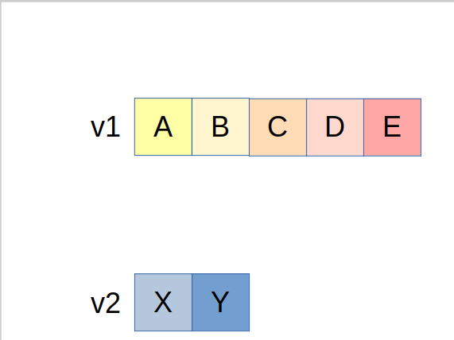

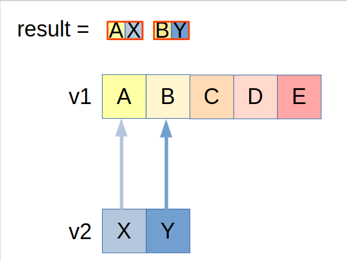

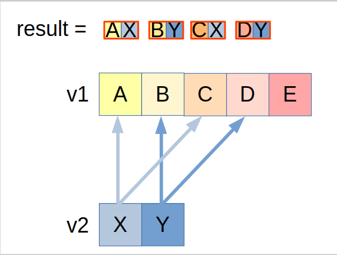

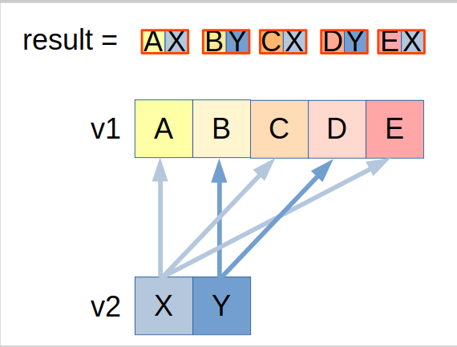

Recycling combines a length-1 vector with every element of a longer vector.  
This is useful for **`vector-by-number arithmetic operations`**:

```r
v <- c(1,4,0,2,-4)
v * 2
```

```
[1]  2  8  0  4 -8
```

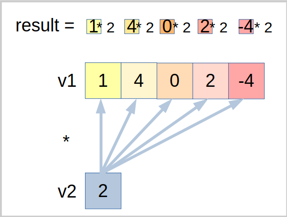

```r
# Create a matrix.
M = matrix( c(2,10,-4,0,7,5.5),
            nrow = 2,
            ncol = 3,
            byrow = TRUE,
            dimnames =
              list(Sex=c("F","M"),Day=1:3))

# Print the matrix
print(M)
```

```
   Day
Sex 1  2    3
  F 2 10 -4.0
  M 0  7  5.5
```

```r
nrow(M) # Get the number of rows
```

```
[1] 2
```

```r
M[1,] # Extract the first row
```

```
 1  2  3
 2 10 -4
```

```r
ncol(M) # Get the number of columns
```

```
[1] 3
```

```r
M[,1] # Extract the first column
```

```
F M
2 0
```

- Visualization
- Code

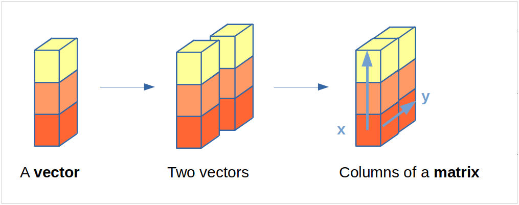

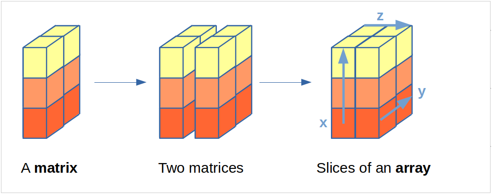

```r
# Create an array with 3 dimensions:
a <- array(dim = c(2,3,2))

# Assume that Dimension 3 (=z) relates to
# two experiments in different conditions,
a[,,1] <- M     # condition 1
a[,,2] <- M + 2 # condition 2

# Print the array
print(a)
```

```
, , 1

     [,1] [,2] [,3]
[1,]    2   10 -4.0
[2,]    0    7  5.5

, , 2

     [,1] [,2] [,3]
[1,]    4   12 -2.0
[2,]    2    9  7.5
```

- “Hooks” …
- … and “Prey”
- Hand-Crafted Object Structure

**`Lists are vectors of a special kind`**.  
A list element is **`not in itself a data value, but a "hook"`** which may attach an arbitrary R object.

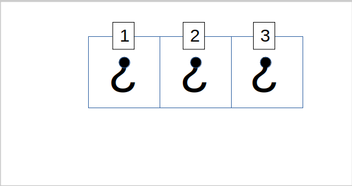

```r
L <- list(c(), c(), c())
length(L)
```

```
[1] 3
```

```r
# L itself has data type "list"
class(L)
```

```
[1] "list"
```

```r
# and each of its elements, too
# (as a vector should!)
class(L[1])
```

```
[1] "list"
```

Each hook can attach an R object:

```r
L <- list(date = date(),
          mouse = c("M5|1"),
          treatment =
            list(
              doses = c(drug1=5,
                        drug2=15),
              technician = "Amy"
            )
     )
```

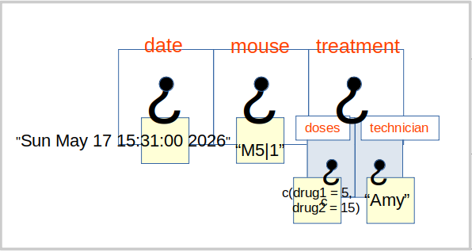

A list can **`mirror the structure of a dataset in an R object`**.  
Individual components can be extracted by index or by name:

```r
#  Double brackets extract the value of an element
L[[2]]
```

```
[1] "M5|1"
```

```r
# Two more ways to retrieve the value:
L[["mouse"]]
```

```
[1] "M5|1"
```

```r
L$mouse
```

```
[1] "M5|1"
```

```r
# Single brackets extract the entire 2nd list element:
L[2]
```

```
$mouse
[1] "M5|1"
```

```r
# Extract a component of a sub-list:
L$treatment$doses
```

```
drug1 drug2
    5    15
```

```r
# Create the data frame
BMI <-  data.frame(
   gender = c("Male", "Male","Female"),
   height = c(152, 171.5, 165),
   weight = c(81,93, 78),
   Age = c(42,38,26)
)

# Print the data frame
print(BMI)
```

```
  gender height weight Age
1   Male  152.0     81  42
2   Male  171.5     93  38
3 Female  165.0     78  26
```

```r
# Print column "Age"
print(BMI[,"Age"]) # alternatively: print(BMI$Age)
```

```
[1] 42 38 26
```

```r
# Print second row:
print(BMI[2,])
```

```
  gender height weight Age
2   Male  171.5     93  38
```

- Definition
- Unordered Factors
- Ordered Factors

**`The factor data type describes relationships between categories`**. A factor variable is **typically used to group another variable** according to these categories, and then **run statistical tests of category differences** on this variable.

Often, the grouping variable and the grouped variable are columns in the same dataframe.

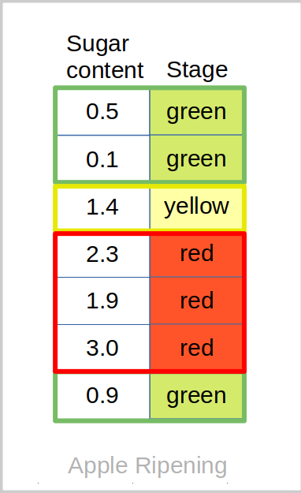

**An unordered factor distinguishes a single base category (= the base level = level 1)**.  
Other categories are tested against this base level.

```r
apple_colors <-
  c('green','green','yellow','red','red','red','green')

df <-
  data.frame(
    sugar = c(0.5, 0.1, 1.4, 2.3, 1.9, 3.0, 0.9),
    color = factor(apple_colors,
                   ordered = FALSE, # default

                   # IF NOT SET, ORDER IS ALPHABETIC!
                   levels = c("green","yellow","red"))
  )
```

```r
print(df)
```

```
  sugar  color
1   0.5  green
2   0.1  green
3   1.4 yellow
4   2.3    red
5   1.9    red
6   3.0    red
7   0.9  green
```

```r
print(df$color)
```

```
[1] green  green  yellow red    red    red    green
Levels: green yellow red
```

**An ordered factor defines an order on all levels**. This allows to test whether the trend of some variable (here: sugar content) follows this order.

```r
df <-
  data.frame(
    sugar = c(0.5, 0.1, 1.4, 2.3, 1.9, 3.0, 0.9),

    # Need to set ordered=TRUE to get an ordered factor!
    color = factor(apple_colors,
                   ordered =TRUE,
                   levels = c("green","yellow","red"))
  )
```

```r
print(df)
```

```
  sugar  color
1   0.5  green
2   0.1  green
3   1.4 yellow
4   2.3    red
5   1.9    red
6   3.0    red
7   0.9  green
```

```r
print(df$color)
```

```
[1] green  green  yellow red    red    red    green
Levels: green < yellow < red
```

## Operators

Operators are the symbols that tell the compiler to perform specific mathematical or logical manipulations. R language is rich in built-in operators and provides the following types of operators −

- Arithmetic
- Relational
- Logical
- Assignment
- Miscellaneous

| Operator | Name | Example |
| --- | --- | --- |
| + | Addition | `x + y` |
| - | Subtraction | `x - y` |
| * | Multiplication | `x * y` |
| / | Division | `x / y` |
| ^ | Exponent | `x ^ y` |
| %% | Modulus (Remainder from division) | `x %% y` |
| %/% | Integer Division | `x%/%y` |

| Operator | Name | Example |
| --- | --- | --- |
| == | Equal | `x == y` |
| != | Not equal | `x != y` |
| > | Greater than | `x > y` |
| < | Less than | `x < y` |
| >= | Greater than or equal to | `x >= y` |
| <= | Less than or equal to | `x <= y` |

| Operator | Description |
| --- | --- |
| && | Statement-wise Logical AND operator: Returns TRUE if left and right statement is TRUE |
| & | Vectorizing Logical AND operator |
| \|\| | Statement-wise Logical OR operator: Returns TRUE if one of the statements is TRUE. |
| \| | Vectorizing Logical OR operator. |
| ! | Logical NOT - returns FALSE if statement is TRUE |

```r
my_var <- 3

3 -> my_var

assign("my_var", c(10.4, 5.6, 3.1, 6.4, 21.7))

my_var # print my_var
```

```
[1] 10.4  5.6  3.1  6.4 21.7
```

| Operator | Description | Example |
| --- | --- | --- |
| : | Creates a series of numbers in a sequence | `x <- 1:10` |
| %in% | Find out if an element belongs to a vector | `x %in% y` |
| %*% | Matrix Multiplication | `x <- Matrix1 %*% Matrix2` |

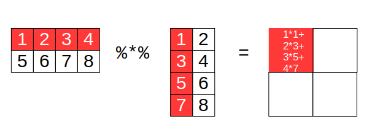

[figure not shown]